# figure1

# Save the newly updated data, excluding unannotated genes

write.csv(final_data, new_file_path, row.names = FALSE, quote = FALSE) }

print("CSV files have been updated.")

Here is the code block extracting the biotypes generated with the above R script

```python
import pandas as pd
import os

# Define the directory containing your updated CSV files
csv_directory="/mnt/work_1/gsgeorge/mus_musculus/figure1"

# Initialize an empty set to store unique gene_biotype values
unique_biotypes = set()

# Loop through each file in the directory
for filename in os.listdir(csv_directory):
    if filename.endswith("_updated.csv"):  # Check if the file is an updated CSV file
        file_path = os.path.join(csv_directory, filename)

        # Read the CSV file
        df = pd.read_csv(file_path)

        # Check if 'gene_biotype' column exists
        if 'gene_biotype' in df.columns:
            # Add unique values from the 'gene_biotype' column to the set
            unique_biotypes.update(df['gene_biotype'].dropna().unique())
        else:
            print(f"'gene_biotype' column not found in {filename}")

# Convert the set to a sorted list
biotypes_list = sorted(list(unique_biotypes))

# Display the unique gene biotypes
print("Unique Gene Biotypes Across All Files:")
for biotype in biotypes_list:
    print(biotype)
```

```
Unique Gene Biotypes Across All Files:
IG_C_gene
IG_D_gene
IG_J_gene
IG_LV_gene
IG_V_gene
IG_V_pseudogene
Mt_tRNA
TEC
TR_C_gene
TR_D_gene
TR_J_gene
TR_V_gene
TR_V_pseudogene
antisense
bidirectional_promoter_lncRNA
lincRNA
lncRNA
macro_lncRNA
miRNA
misc_RNA
polymorphic_pseudogene
processed_pseudogene
processed_transcript
protein_coding
pseudogene
ribozyme
scaRNA
sense_intronic
sense_overlapping
snRNA
snoRNA
transcribed_processed_pseudogene
transcribed_unitary_pseudogene
transcribed_unprocessed_pseudogene
translated_unprocessed_pseudogene
unitary_pseudogene
unprocessed_pseudogene
```

Below I am going to generate Up, Down, and Unregulated gene lists for each tissue in keenly named output directories using the os package

```python
import os
import pandas as pd

# Input directory containing the input files.
input_dir = '/mnt/work_1/gsgeorge/mus_musculus/figure1'
# Output directory where the organized subdirectories and files will be saved.
output_dir = '/mnt/work_1/gsgeorge/mus_musculus/figure1/output'

# Create the output directory if it doesn't exist.
os.makedirs(output_dir, exist_ok=True)

# Process each file in the input directory.
for filename in os.listdir(input_dir):

    # Only process CSV files that end with 'updated.csv'.
    if not filename.endswith('updated.csv'):
        continue

    tissue_name = filename.split('_')[0]  # Extract tissue name from filename.
    df = pd.read_csv(os.path.join(input_dir, filename))
    #drop doups
    df.drop_duplicates(subset='ID', keep='first', inplace=True)

    # Remove any rows with NA values before classification.
    df.dropna(inplace=True)

    # Classify each gene based on log2FoldChange and padj.
    df['Regulation'] = 'unregulated'
    df.loc[(df['padj'] <= 0.05) & (df['log2FoldChange'] >= 1), 'Regulation'] = 'upregulated'
    df.loc[(df['padj'] <= 0.05) & (df['log2FoldChange'] <= -1), 'Regulation'] = 'downregulated'

    # Group data into three categories.
    upregulated_df = df[df['Regulation'] == 'upregulated']
    downregulated_df = df[df['Regulation'] == 'downregulated']
    unregulated_df = df[df['Regulation'] == 'unregulated']

    # Create a subdirectory for the tissue if it doesn't exist.
    tissue_dir = os.path.join(output_dir, tissue_name)
    os.makedirs(tissue_dir, exist_ok=True)

    # Define filenames for each regulation type.
    upregulated_file = os.path.join(tissue_dir, f'{tissue_name}_upregulated_annotated.csv')
    downregulated_file = os.path.join(tissue_dir, f'{tissue_name}_downregulated_annotated.csv')
    unregulated_file = os.path.join(tissue_dir, f'{tissue_name}_unregulated_annotated.csv')

    # Save the filtered dataframes to their corresponding files.
    upregulated_df.to_csv(upregulated_file, index=False)
    downregulated_df.to_csv(downregulated_file, index=False)
    unregulated_df.to_csv(unregulated_file, index=False)

print("Processing completed!")
```

```
Processing completed!
```

Then after conducing QC on these .csv files below I am going to generate an overall volcano plot across all tissues and genes with only x axis limited from -10,10 which includes all transcripts even if removed. There is no y limit applied so all genes in this plot are all genes across all tissues annotated by biomart.

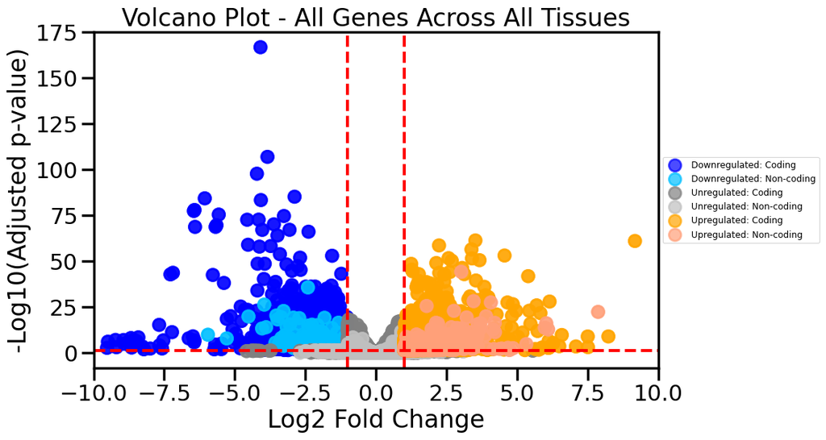

```python
import os
import glob
import pandas as pd
import numpy as np
import matplotlib.pyplot as plt
import seaborn as sns

output_dir = '/mnt/work_1/gsgeorge/mus_musculus/figure1/output/all_output'
os.makedirs(output_dir, exist_ok=True)

def apply_color_and_label(row):
    color_map = {
        'upregulated_Coding': ("orange", "Upregulated: Coding"),
        'upregulated_Non-Coding': ("#FFA07A", "Upregulated: Non-coding"),
        'downregulated_Coding': ("blue", "Downregulated: Coding"),
        'downregulated_Non-Coding': ("deepskyblue", "Downregulated: Non-coding"),
        'unregulated_Coding': ("gray", "Unregulated: Coding"),
        'unregulated_Non-Coding': ("silver", "Unregulated: Non-coding"),
    }
    key = f"{row['Regulation']}_{row['Coding/Non-coding']}"
    return color_map.get(key, ("black", "Unknown"))

input_dir = '/mnt/work_1/gsgeorge/mus_musculus/figure1/output'

all_genes = []
for directory in glob.glob(os.path.join(input_dir, '*')):
    if os.path.isdir(directory):
        for filename in glob.glob(os.path.join(directory, '*.csv')):
            df = pd.read_csv(filename)
            tissue = os.path.basename(directory)
            df['Tissue'] = tissue
            if "upregulated" in filename:
                df['Regulation'] = 'upregulated'
            elif "downregulated" in filename:
                df['Regulation'] = 'downregulated'
            else:
                df['Regulation'] = 'unregulated'
            all_genes.append(df)

df_all_genes = pd.concat(all_genes, ignore_index=True)
df_all_genes["-log10(padj)"] = -np.log10(df_all_genes["padj"])

df_all_genes["color"], df_all_genes["label"] = zip(*df_all_genes.apply(apply_color_and_label, axis=1))

# Creating the plot
plt.figure(figsize=(10, 6))
# Plotting each category individually to handle legends correctly
for label, group_df in df_all_genes.groupby("label"):
    plt.scatter(group_df["log2FoldChange"], group_df["-log10(padj)"], c=group_df["color"], label=label, alpha=0.7)

plt.title("Volcano Plot - All Genes Across All Tissues")
plt.xlabel('Log2 Fold Change')
plt.ylabel('-Log10(Adjusted p-value)')
plt.axhline(y=-np.log10(0.05), color='r', linestyle='--')
plt.axvline(x=1, color='r', linestyle='--')
plt.axvline(x=-1, color='r', linestyle='--')

plt.xlim(-10, 10)  # Adjust as needed for your data
sns.set_context('paper')
plt.legend(loc='center left', bbox_to_anchor=(1, 0.5))
# plt.tight_layout()
volcano_plot_path = os.path.join(output_dir, "volcano_plot_all_tissues.svg")
plt.savefig(volcano_plot_path, format="svg", bbox_inches='tight')
plt.show()
```

Now I will break down this volcano plot into pie charts color coordinated with the same legend

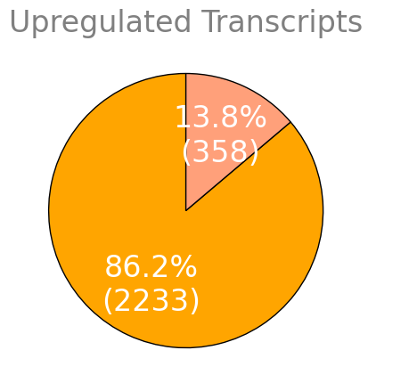

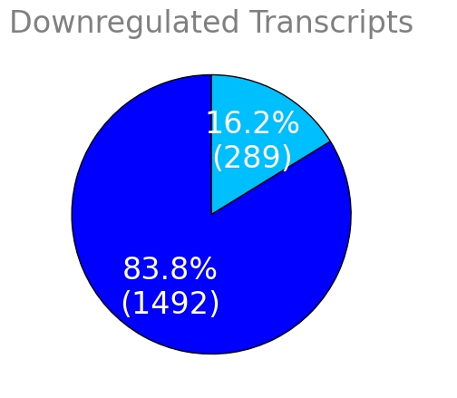

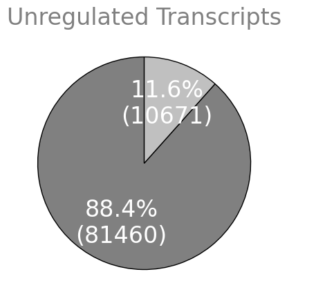

```python
import os
import pandas as pd
import matplotlib.pyplot as plt
import seaborn as sns

def read_and_concatenate_csv_files(input_dir):
    all_genes = []
    annotation_dirs = ['BM', 'Kidney', 'Liver', 'Lung', 'Ovary', 'Spleen']
    for annotation_dir in annotation_dirs:
        dir_path = os.path.join(input_dir, 'output', annotation_dir)
        for filename in os.listdir(dir_path):
            if filename.endswith('.csv'):
                csv_path = os.path.join(dir_path, filename)
                df = pd.read_csv(csv_path)
                if "upregulated" in filename:
                    df['Regulation'] = 'upregulated'
                elif "downregulated" in filename:
                    df['Regulation'] = 'downregulated'
                else:
                    df['Regulation'] = 'unregulated'
                df['Tissue'] = annotation_dir
                all_genes.append(df)
    return pd.concat(all_genes, ignore_index=True)

def plot_pies_for_all_categories_with_counts(df, output_dir):
    sns.set_context("poster")

    color_map = {
        'upregulated_Coding': "orange",
        'upregulated_Non-Coding': "#FFA07A",
        'downregulated_Coding': "blue",
        'downregulated_Non-Coding': "deepskyblue",
        'unregulated_Coding': "gray",
        'unregulated_Non-Coding': "silver",
    }

    def make_autopct(values):
        def my_autopct(pct):
            total = sum(values)
            count = int(round(pct*total/100.0))
            return f"{pct:.1f}%\n({count})"
        return my_autopct

    os.makedirs(output_dir, exist_ok=True)

    for category in ['upregulated', 'downregulated', 'unregulated']:
        df_subset = df[df['Regulation'] == category]
        if not df_subset.empty:
            coding_counts = df_subset['Coding/Non-coding'].value_counts()
            labels = ['Coding', 'Non-Coding']
            values = [coding_counts.get(label, 0) for label in labels]
            colors = [color_map[f"{category}_{label}"] for label in labels]
            plt.figure(figsize=(5, 5))
            patches, texts, autotexts = plt.pie(
                values, labels=labels, colors=colors, autopct=make_autopct(values), startangle=90,
                wedgeprops=dict(edgecolor='black', linewidth=1)
            )
            for text in texts + autotexts:
                text.set_color("white")
            plt.title(f"{category.capitalize()} Transcripts", color="gray")
            svg_filename = os.path.join(output_dir, f"{category}_transcripts_pie_chart.svg")
            plt.savefig(svg_filename, format='svg', bbox_inches='tight')
            plt.show()

input_dir = '/mnt/work_1/gsgeorge/mus_musculus/figure1'
output_dir = '/mnt/work_1/gsgeorge/mus_musculus/figure1/output/all_output/pie_charts'

df_all_genes = read_and_concatenate_csv_files(input_dir)

plot_pies_for_all_categories_with_counts(df_all_genes, output_dir)
```

Below using an os walk I will generate the x-axis limited and y-axis non-limited volcano plots for each tissue. Outputing them with accurate naming conventions and saved in the all_output directory

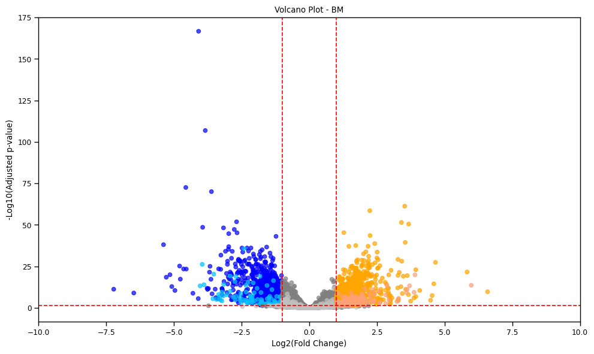

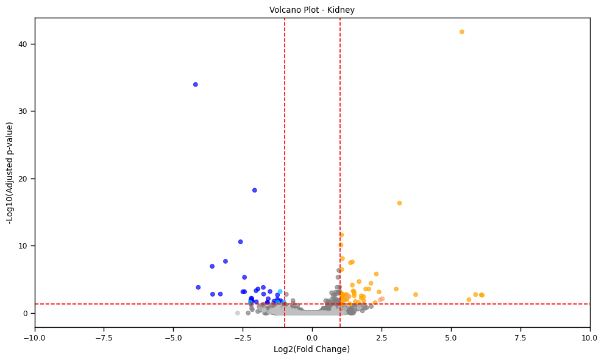

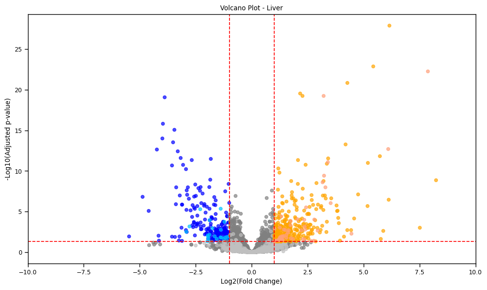

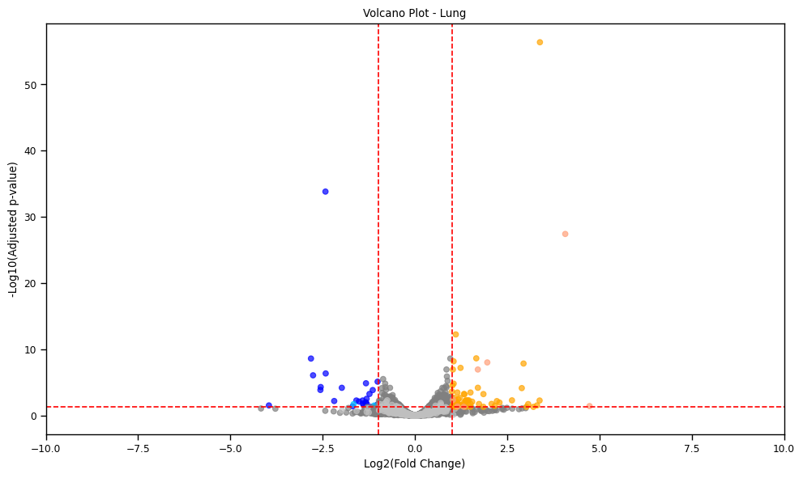

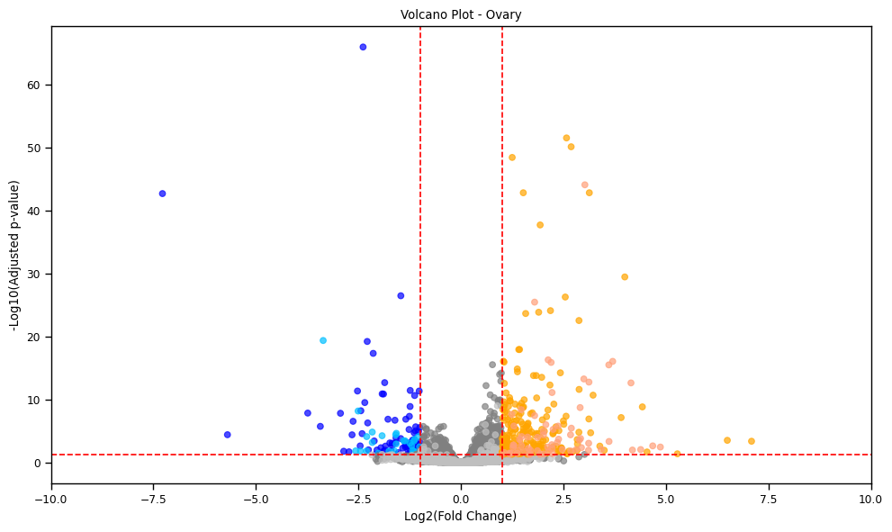

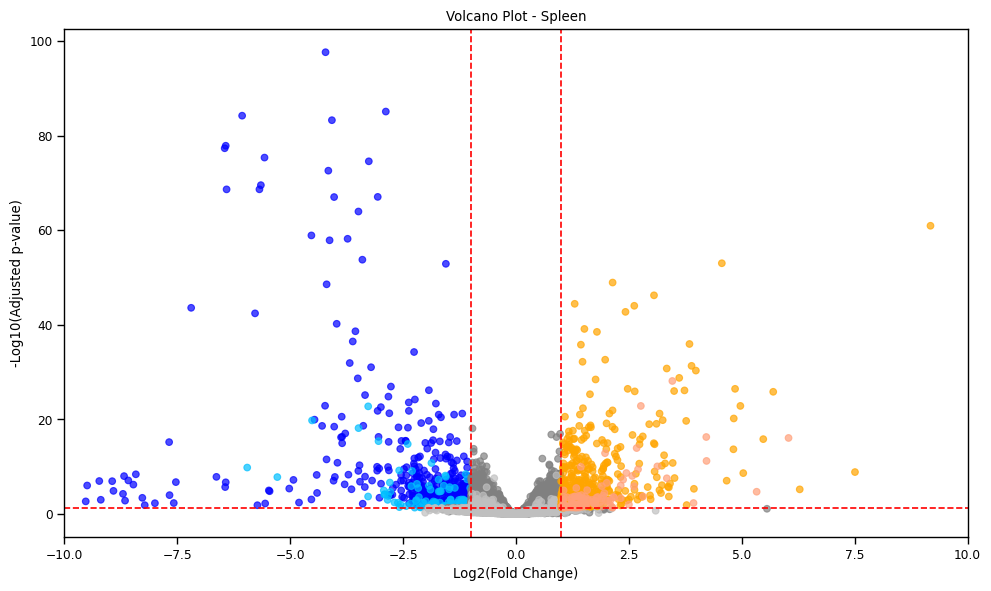

```
Volcano plots for each tissue have been generated and saved using specified color coordination.
```

```python
import os
import pandas as pd
import numpy as np
import matplotlib.pyplot as plt
import seaborn as sns

data_dir = '/mnt/work_1/gsgeorge/mus_musculus/figure1/output'
output_dir_volcano = '/mnt/work_1/gsgeorge/mus_musculus/figure1/output/all_output/volcano_plots'

if not os.path.exists(output_dir_volcano):
    os.makedirs(output_dir_volcano)

def apply_color_and_label(row):
    color_map = {
        'upregulated_Coding': ("orange", "Upregulated: Coding"),
        'upregulated_Non-Coding': ("#FFA07A", "Upregulated: Non-coding"),
        'downregulated_Coding': ("blue", "Downregulated: Coding"),
        'downregulated_Non-Coding': ("deepskyblue", "Downregulated: Non-coding"),
        'unregulated_Coding': ("gray", "Unregulated: Coding"),
        'unregulated_Non-Coding': ("silver", "Unregulated: Non-coding"),
        'Other': ("black", "Uncategorized")
    }

    if 'Coding/Non-coding' in row:
        bio_type = row['Coding/Non-coding']
        if isinstance(bio_type, str):
            key = f"{row['Regulation']}_{bio_type.replace(' ', '_')}"
        else:
            key = 'Other'
    else:
        key = 'Other'

    return color_map.get(key, color_map['Other'])

sns.set_context('paper')

def process_tissue_files_for_volcano(tissue_name, data_dir, output_dir):
    all_genes = pd.DataFrame()

    for regulation in ['upregulated', 'downregulated', 'unregulated']:
        filename = os.path.join(data_dir, tissue_name, f"{tissue_name}_{regulation}_annotated.csv")
        if os.path.exists(filename):
            df = pd.read_csv(filename)
            df['Regulation'] = regulation
            all_genes = pd.concat([all_genes, df], ignore_index=True)

    if not all_genes.empty:
        all_genes["-log10(padj)"] = -np.log10(all_genes["padj"].replace(0, np.nan))  # Adjusting for 0 padj values
        all_genes[['color', 'label']] = all_genes.apply(apply_color_and_label, axis=1, result_type='expand')

        plt.figure(figsize=(10, 6))
        for _, group_df in all_genes.groupby("label"):
            plt.scatter(group_df["log2FoldChange"], group_df["-log10(padj)"], c=group_df['color'], label=_, alpha=0.7)

        plt.title(f"Volcano Plot - {tissue_name}")
        plt.xlabel('Log2(Fold Change)')
        plt.ylabel('-Log10(Adjusted p-value)')
        plt.axhline(y=-np.log10(0.05), color='r', linestyle='--')
        plt.axvline(x=1, color='r', linestyle='--')
        plt.axvline(x=-1, color='r', linestyle='--')
        # plt.ylim(0, max(all_genes["-log10(padj)"].dropna())*1.1)  # Adjust ylim dynamically
        plt.xlim(-10,10)


        # plt.legend()
        sns.set_context('paper')
        plt.tight_layout()
        output_path = os.path.join(output_dir, f"volcano_plot_{tissue_name}.svg")
        plt.savefig(output_path, format='svg', bbox_inches='tight')
        plt.show()  # To prevent display while running in scripts

# List of tissues reflects the directory names under 'output'
tissues = ['BM', 'Kidney', 'Liver', 'Lung', 'Ovary', 'Spleen']
for tissue in tissues:
    process_tissue_files_for_volcano(tissue, data_dir, output_dir_volcano)

print("Volcano plots for each tissue have been generated and saved using specified color coordination.")
```

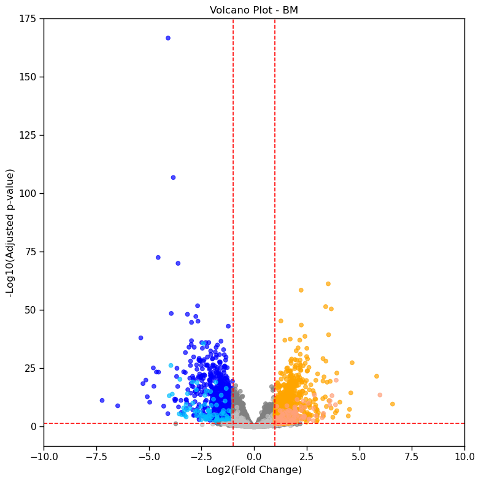

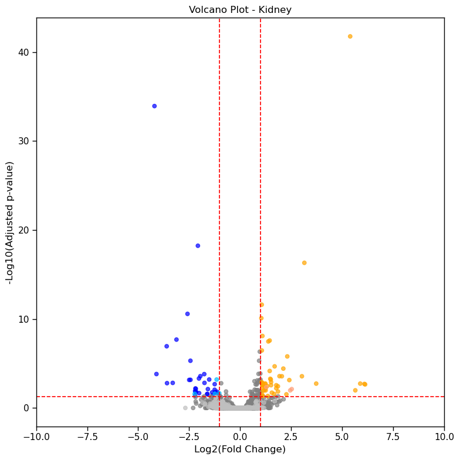

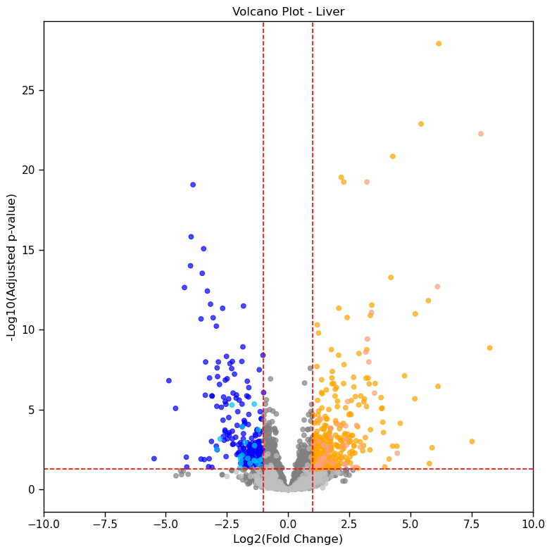

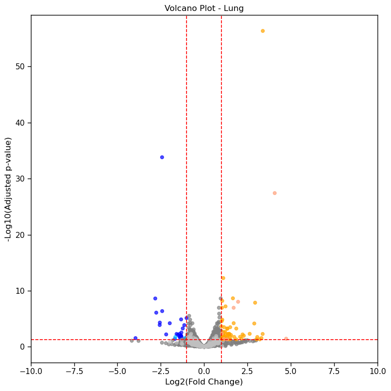

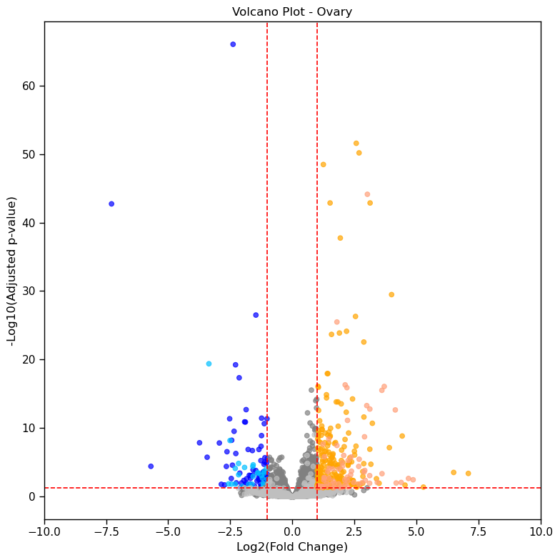

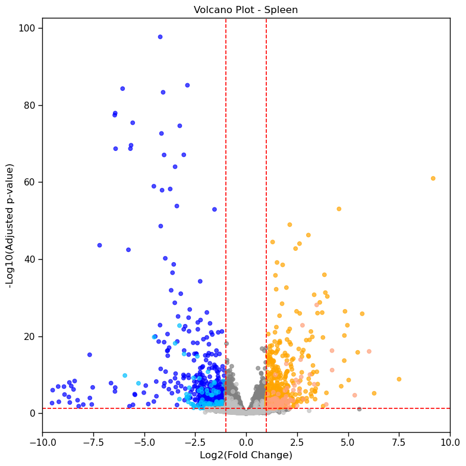

```
Volcano plots for each tissue have been generated and saved using specified color coordination.
```

```python
import os
import pandas as pd
import numpy as np
import matplotlib.pyplot as plt
import seaborn as sns

data_dir = '/mnt/work_1/gsgeorge/mus_musculus/figure1/output'
output_dir_volcano = '/mnt/work_1/gsgeorge/mus_musculus/figure1/output/all_output/volcano_plots'

if not os.path.exists(output_dir_volcano):
    os.makedirs(output_dir_volcano)

def apply_color_and_label(row):
    color_map = {
        'upregulated_Coding': ("orange", "Upregulated: Coding"),
        'upregulated_Non-Coding': ("#FFA07A", "Upregulated: Non-coding"),
        'downregulated_Coding': ("blue", "Downregulated: Coding"),
        'downregulated_Non-Coding': ("deepskyblue", "Downregulated: Non-coding"),
        'unregulated_Coding': ("gray", "Unregulated: Coding"),
        'unregulated_Non-Coding': ("silver", "Unregulated: Non-coding"),
        'Other': ("black", "Uncategorized")
    }

    if 'Coding/Non-coding' in row:
        bio_type = row['Coding/Non-coding']
        if isinstance(bio_type, str):
            key = f"{row['Regulation']}_{bio_type.replace(' ', '_')}"
        else:
            key = 'Other'
    else:
        key = 'Other'

    return color_map.get(key, color_map['Other'])

sns.set_context('paper', font_scale= 1.25)

def process_tissue_files_for_volcano(tissue_name, data_dir, output_dir):
    all_genes = pd.DataFrame()

    for regulation in ['upregulated', 'downregulated', 'unregulated']:
        filename = os.path.join(data_dir, tissue_name, f"{tissue_name}_{regulation}_annotated.csv")
        if os.path.exists(filename):
            df = pd.read_csv(filename)
            df['Regulation'] = regulation
            all_genes = pd.concat([all_genes, df], ignore_index=True)

    if not all_genes.empty:
        all_genes["-log10(padj)"] = -np.log10(all_genes["padj"].replace(0, np.nan))  # Adjusting for 0 padj values
        all_genes[['color', 'label']] = all_genes.apply(apply_color_and_label, axis=1, result_type='expand')

        plt.figure(figsize=(8, 8))
        for _, group_df in all_genes.groupby("label"):
            plt.scatter(group_df["log2FoldChange"], group_df["-log10(padj)"], c=group_df['color'], label=_, alpha=0.7)

        plt.title(f"Volcano Plot - {tissue_name}")
        plt.xlabel('Log2(Fold Change)')
        plt.ylabel('-Log10(Adjusted p-value)')
        plt.axhline(y=-np.log10(0.05), color='r', linestyle='--')
        plt.axvline(x=1, color='r', linestyle='--')
        plt.axvline(x=-1, color='r', linestyle='--')
        # plt.ylim(0, max(all_genes["-log10(padj)"].dropna())*1.1)  # Adjust ylim dynamically
        plt.xlim(-10,10)


        # plt.legend()
        plt.tight_layout()
        output_path = os.path.join(output_dir, f"volcano_plot_{tissue_name}_figure1.svg")
        plt.savefig(output_path, format='svg', bbox_inches='tight')
        plt.show()  # To prevent display while running in scripts

# List of tissues reflects the directory names under 'output'
tissues = ['BM', 'Kidney', 'Liver', 'Lung', 'Ovary', 'Spleen']
for tissue in tissues:
    process_tissue_files_for_volcano(tissue, data_dir, output_dir_volcano)

print("Volcano plots for each tissue have been generated and saved using specified color coordination.")
```

```
Setting up output directories
Processing BM
```

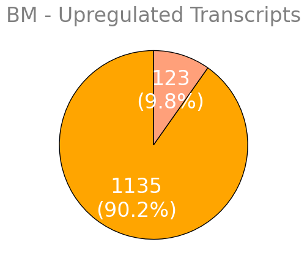

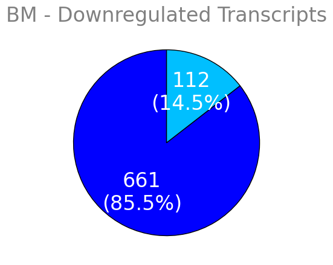

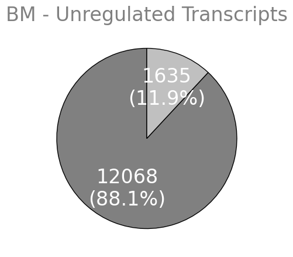

```
Processing Kidney
```

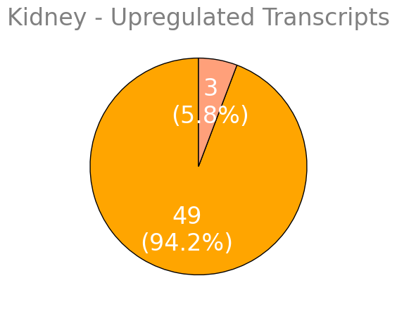

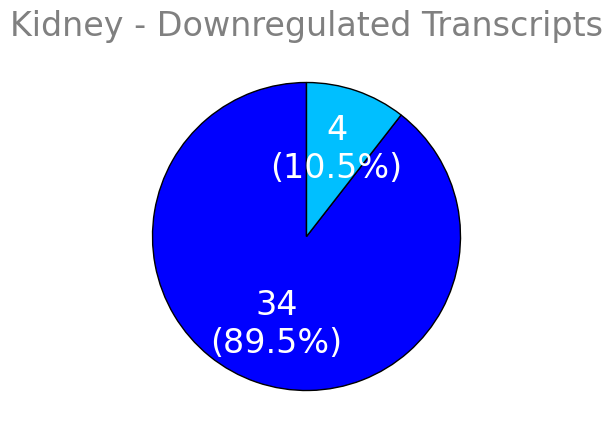

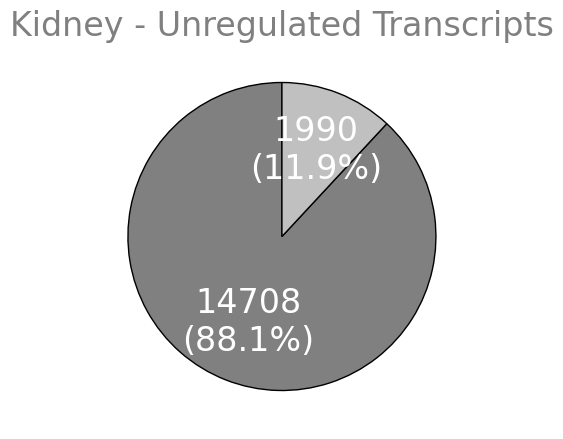

```
Processing Liver
```

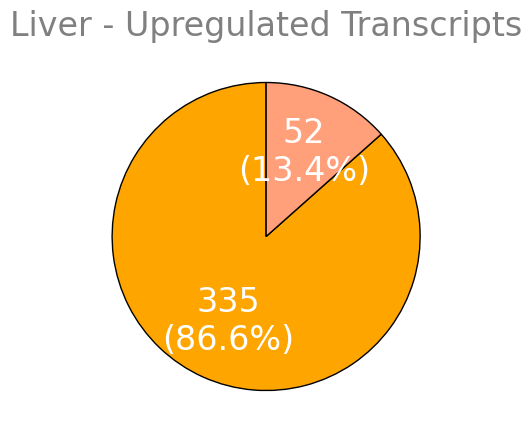

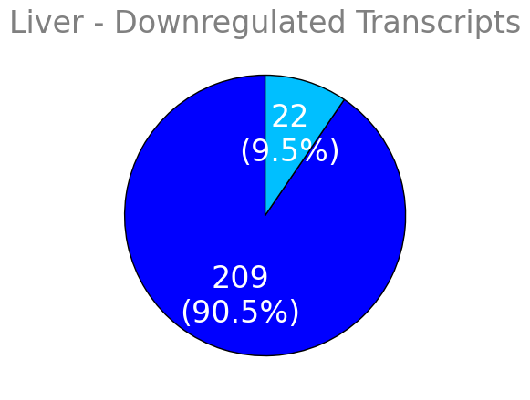

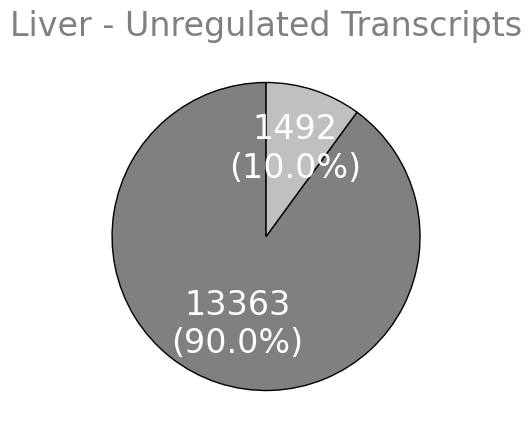

```
Processing Lung
```

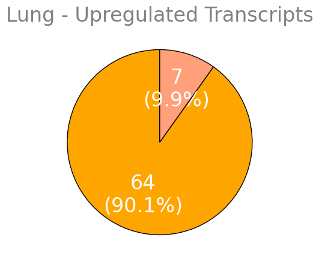

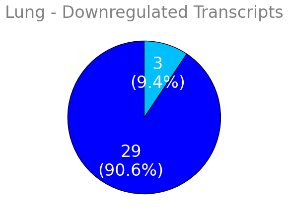

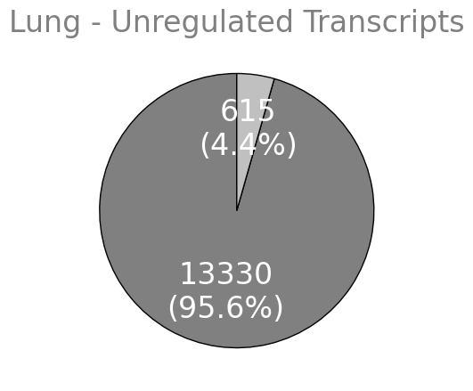

```
Processing Ovary
```

[6 more figures not shown]

```
Pie charts for each tissue and category have been generated and saved with color coordination, including counts and percentages inside the pie slices.
```

```python
import matplotlib.pyplot as plt
import pandas as pd
import numpy as np
import os
import seaborn as sns

def custom_autopct(counts):
    def func(pct):
        total = sum(counts)
        val = int(round(pct*total/100.0))
        return f"{val}\n({pct:.1f}%)" if pct > 0 else ''  # Changed from f"{val} ({pct:.1f}%)" to f"{val}\n({pct:.1f}%)"
    return func

def plot_pies_for_all_categories_with_counts_inside(df, tissue_name, output_dir):
    sns.set_context("poster")

    color_map = {
        'upregulated_Coding': "orange",
        'upregulated_Non-Coding': "#FFA07A",
        'downregulated_Coding': "blue",
        'downregulated_Non-Coding': "deepskyblue",
        'unregulated_Coding': "gray",
        'unregulated_Non-Coding': "silver",
    }

    # Ensuring 'Coding/Non-coding' column exists and defaulting missing values to 'Non-Coding'
    if 'Coding/Non-coding' not in df.columns:
        df['Coding/Non-coding'] = 'Non-Coding'
    else:
        df['Coding/Non-coding'] = df['Coding/Non-coding'].fillna('Non-Coding')

    categories = ['upregulated', 'downregulated', 'unregulated']
    for category in categories:
        df_subset = df[df['Regulation'] == category]
        if not df_subset.empty:
            # Generating counts
            counts = df_subset['Coding/Non-coding'].value_counts()
            labels = counts.index
            coding_status_counts = counts.values

            # Defining colors based on labels
            colors = [color_map[f"{category}_{label.replace(' ', '_')}"] for label in labels]

            plt.figure(figsize=(5, 5))
            patches, texts, autotexts = plt.pie(
                coding_status_counts, labels=labels, colors=colors, autopct=custom_autopct(coding_status_counts), startangle=90,
                wedgeprops=dict(edgecolor='black', linewidth=1)
            )
            for text in texts + autotexts:
                text.set_color("white")
            plt.title(f"{tissue_name} - {category.capitalize()} Transcripts", color="gray")

            svg_filename = os.path.join(output_dir, f"{tissue_name}_{category}_transcripts_pie_chart_counts_inside.svg")
            plt.savefig(svg_filename, format='svg', bbox_inches='tight')
            plt.show()  # Use plt.close() to avoid showing plots when running in non-interactive environments

print("Setting up output directories")
output_dir_pies = '/mnt/work_1/gsgeorge/mus_musculus/figure1/output/all_output/pie_charts'
os.makedirs(output_dir_pies, exist_ok=True)

data_dir = '/mnt/work_1/gsgeorge/mus_musculus/figure1/output'  # Adjust based on your actual data directory
tissues = ['BM', 'Kidney', 'Liver', 'Lung', 'Ovary', 'Spleen']  # List of directories to process

for tissue_name in tissues:
    print(f"Processing {tissue_name}")
    tissue_dir = os.path.join(data_dir, tissue_name)
    all_genes = pd.DataFrame()

    for regulation in ['upregulated', 'downregulated', 'unregulated']:
        filename = os.path.join(tissue_dir, f"{tissue_name}_{regulation}_annotated.csv")
        if os.path.exists(filename):
            df = pd.read_csv(filename)
            df['Regulation'] = regulation
            all_genes = pd.concat([all_genes, df], ignore_index=True)

    if not all_genes.empty:
        plot_pies_for_all_categories_with_counts_inside(all_genes, tissue_name, output_dir_pies)

print("Pie charts for each tissue and category have been generated and saved with color coordination, including counts and percentages inside the pie slices.")
```

This is all that is needed to produce figure one

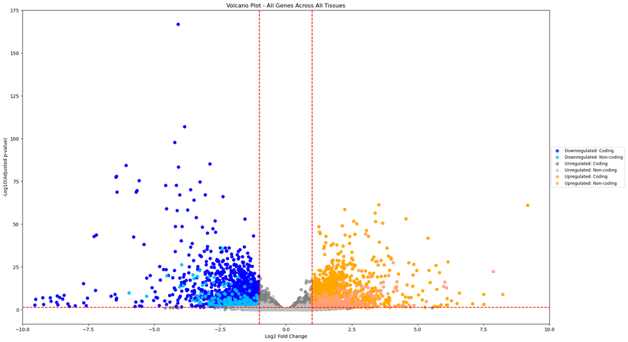

```python
import os
import glob
import pandas as pd
import numpy as np
import matplotlib.pyplot as plt
import seaborn as sns

output_dir = '/mnt/work_1/gsgeorge/mus_musculus/figure1/output/all_output'
os.makedirs(output_dir, exist_ok=True)

def apply_color_and_label(row):
    color_map = {
        'upregulated_Coding': ("orange", "Upregulated: Coding"),
        'upregulated_Non-Coding': ("#FFA07A", "Upregulated: Non-coding"),
        'downregulated_Coding': ("blue", "Downregulated: Coding"),
        'downregulated_Non-Coding': ("deepskyblue", "Downregulated: Non-coding"),
        'unregulated_Coding': ("gray", "Unregulated: Coding"),
        'unregulated_Non-Coding': ("silver", "Unregulated: Non-coding"),
    }
    key = f"{row['Regulation']}_{row['Coding/Non-coding']}"
    return color_map.get(key, ("black", "Unknown"))

input_dir = '/mnt/work_1/gsgeorge/mus_musculus/figure1/output'

all_genes = []
for directory in glob.glob(os.path.join(input_dir, '*')):
    if os.path.isdir(directory):
        for filename in glob.glob(os.path.join(directory, '*.csv')):
            df = pd.read_csv(filename)
            tissue = os.path.basename(directory)
            df['Tissue'] = tissue
            if "upregulated" in filename:
                df['Regulation'] = 'upregulated'
            elif "downregulated" in filename:
                df['Regulation'] = 'downregulated'
            else:
                df['Regulation'] = 'unregulated'
            all_genes.append(df)

df_all_genes = pd.concat(all_genes, ignore_index=True)

# Remove duplicates based on gene ID for unregulated genes, keeping the first occurrence
df_unregulated_unique = (df_all_genes[df_all_genes['Regulation'] == 'unregulated']
                         .drop_duplicates(subset='ID'))
df_up_down = df_all_genes[df_all_genes['Regulation'] != 'unregulated']
df_all_genes = pd.concat([df_up_down, df_unregulated_unique], ignore_index=True)

df_all_genes["-log10(padj)"] = -np.log10(df_all_genes["padj"])
df_all_genes["color"], df_all_genes["label"] = zip(*df_all_genes.apply(apply_color_and_label, axis=1))

# Creating the plot
plt.figure(figsize=(20, 12))
for label, group_df in df_all_genes.groupby("label"):
    plt.scatter(group_df["log2FoldChange"], group_df["-log10(padj)"], c=group_df["color"], label=label, alpha=0.7)

plt.title("Volcano Plot - All Genes Across All Tissues")
plt.xlabel('Log2 Fold Change')
plt.ylabel('-Log10(Adjusted p-value)')
plt.axhline(y=-np.log10(0.05), color='r', linestyle='--')
plt.axvline(x=1, color='r', linestyle='--')
plt.axvline(x=-1, color='r', linestyle='--')

plt.xlim(-10, 10)  # Adjust as needed for your data
sns.set_context('paper')
plt.legend(loc='center left', bbox_to_anchor=(1, 0.5))
volcano_plot_path = os.path.join(output_dir, "volcano_plot_all_tissues_unique_unregulated.svg")
plt.savefig(volcano_plot_path, format="svg", bbox_inches='tight')
plt.show()
```